# Taller en clase — Riesgo y distribución

Resuelve los 15 puntos de la actividad **“Riesgo y distribución”** sobre el portafolio de 5 ETFs de la unidad de *Retornos y portafolios manuales* — pero esta vez con **retornos semanales**, VaR/ES a 99% de confianza a 1 semana, y ventana móvil de **6 meses (26 semanas)**.

## Configuración inicial

```r
if (!require("pacman")) install.packages("pacman")
```

```r
pacman::p_load(tidyverse, EnvStats, ggpubr, psych, quantmod, TTR,
               purrr, PerformanceAnalytics, highcharter, timetk, readxl, scales)
options(scipen = 999)
```

# Parte 0 — Reconstrucción del portafolio (retornos semanales)

```r
symbols <- c("SPY","EFA", "IJS", "EEM", "AGG")

precios <- quantmod::getSymbols(symbols,
                                src = 'yahoo',
                                from = "2010-12-31",
                                periodicity = "daily",
                                auto.assign = TRUE,
                                warnings = FALSE) %>%
    purrr::map(~quantmod::Ad(get(.))) %>%
    purrr::reduce(merge.xts) %>%
    `colnames<-`(symbols)

precios_semana <- xts::to.weekly(x = precios, OHLC = FALSE)
retornos_semana <- diff(log(precios_semana)) %>% na.omit()

retornos_semana_long <- retornos_semana %>%
    tk_tbl(rename_index = "date") %>%
    gather(key = activo, value = retorno, -date, factor_key = T)

w <- c(0.25, 0.25, 0.20, 0.20, 0.10)

portfolio_retornos_semana <- PerformanceAnalytics::Return.portfolio(R = retornos_semana,
                                                                     weights = w,
                                                                     rebalance_on = "weeks") %>%
  `colnames<-`("retornos")

ventana <- 26 # 6 meses en semanas
alpha <- 0.01 # 99% de confianza

tail(portfolio_retornos_semana)
```

```
##                retornos
## 2026-08-21 -0.006198275
## 2026-08-28 -0.001122799
## 2026-09-04  0.006181724
## 2026-09-11 -0.013552922
## 2026-09-18 -0.010892792
## 2026-09-21  0.012077963
```

[output not shown]

# 1 — Desviación estándar por activo

```r
PerformanceAnalytics::StdDev(R = retornos_semana)*100
```

```
##             SPY      EFA      IJS      EEM       AGG
## StdDev 2.230839 2.367111 3.033078 2.722037 0.6386226
```

**Respuesta:** la desviación estándar semanal va de **0.64%** (AGG, renta fija) a **3.03%** (IJS, small-cap value) — el orden de mayor a menor riesgo es IJS > EEM > EFA > SPY > AGG, exactamente lo que se esperaría por tipo de activo: la renta fija (AGG) es, con amplio margen, el más estable (menos de un tercio de la volatilidad de cualquier acción), y dentro de renta variable, small-caps (IJS) y mercados emergentes (EEM) son más volátiles que el mercado desarrollado grande (SPY) y EAFE (EFA).

# 2 — Desviación estándar del portafolio

```r
PerformanceAnalytics::StdDev(R = retornos_semana, weights = w)*100
```

```
##          [,1]
## [1,] 2.104641
```

**Respuesta:** el portafolio combinado tiene una desviación estándar semanal de **2.10%** — **menor que cualquiera de los 4 componentes de renta variable** (SPY, EFA, IJS, EEM), aunque por encima de AGG solo. Es el efecto de diversificación esperado: al combinar activos que no están perfectamente correlacionados, el riesgo del conjunto es menor que el promedio ponderado de sus componentes.

# 3 — Retornos semanales del portafolio vs. ±1 desviación estándar

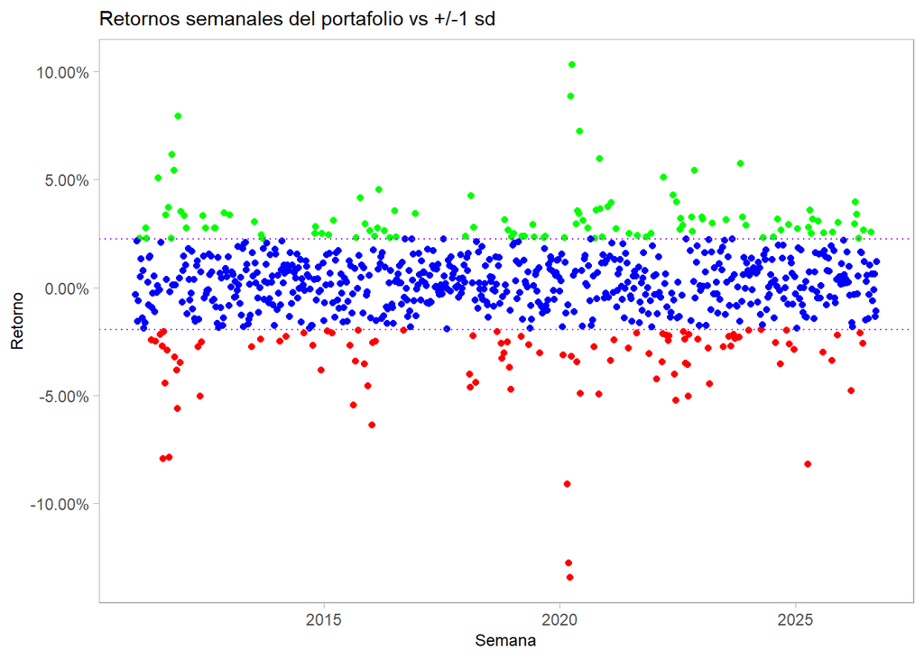

```r
sd_plot <- sd(portfolio_retornos_semana)
mean_plot <- mean(portfolio_retornos_semana)

portfolio_retornos_semana %>%
  as.data.frame() %>%
  rownames_to_column(var = "Fecha") %>%
  mutate(Fecha = ymd(Fecha)) %>%
  mutate(hist_col_red = if_else(retornos < (mean_plot - sd_plot),
                                retornos, as.numeric(NA)),
         hist_col_green = if_else(retornos > (mean_plot + sd_plot),
                                  retornos, as.numeric(NA)),
         hist_col_blue = if_else(retornos >= (mean_plot - sd_plot) & retornos <= (mean_plot + sd_plot),
                                 retornos, as.numeric(NA))) %>%
  ggplot(aes(x = Fecha)) +
  geom_point(aes(y = hist_col_red), color = "red") +
  geom_point(aes(y = hist_col_green), color = "green") +
  geom_point(aes(y = hist_col_blue), color = "blue") +
  geom_hline(yintercept = (mean_plot + sd_plot), color = "purple", linetype = "dotted") +
  geom_hline(yintercept = (mean_plot - sd_plot), color = "purple", linetype = "dotted") +
  labs(title = "Retornos semanales del portafolio vs +/-1 sd", y = "Retorno", x = "Semana") +
  scale_x_date(breaks = pretty_breaks(n = 6)) +
  scale_y_continuous(labels = label_percent(accuracy = 0.01)) +
  theme_light() +
  theme(plot.title = element_text(size = 11),
        axis.title = element_text(size = 9),
        panel.grid = element_blank())
```

**Respuesta:** en azul quedan las semanas “normales” (dentro de ±1 sd de la media), en rojo las caídas grandes y en verde las subidas grandes. Con una distribución normal se esperaría ~68% de los puntos en azul — a simple vista hay bastantes puntos rojos agrupados en episodios concretos (las crisis de 2011, 2015-16, 2018, marzo de 2020 y 2022) en vez de estar repartidos uniformemente en el tiempo, la primera señal visual de que la distribución real no es tan “bien portada” como una normal (coherente con la asimetría negativa y la curtosis alta que se calculan más adelante).

# 4 — Desviación estándar vs. retorno esperado

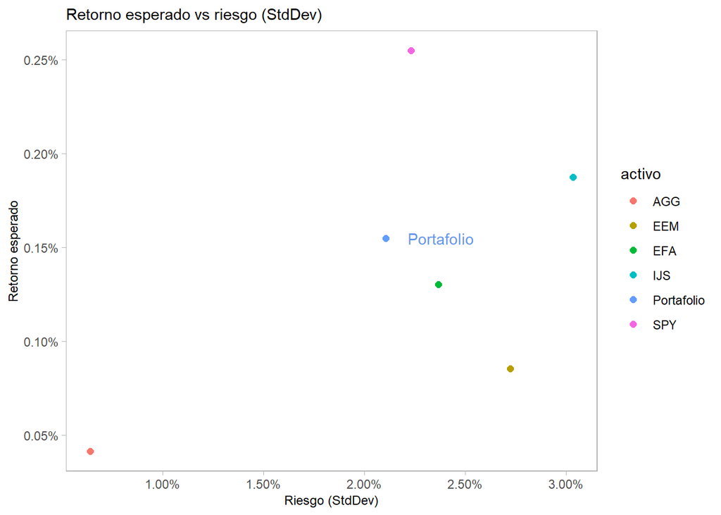

```r
retornos_semana_long %>%
  group_by(activo) %>%
  summarise(retorno_esperado = mean(retorno), desviacion = sd(retorno)) %>%
  add_row(activo = "Portafolio",
          desviacion = sd(portfolio_retornos_semana),
          retorno_esperado = mean(portfolio_retornos_semana)) %>%
  ggplot(aes(x = desviacion, y = retorno_esperado, color = activo)) +
  geom_point(size = 2) +
  annotate("text", x = sd(portfolio_retornos_semana) * 1.13, y = mean(portfolio_retornos_semana),
           label = "Portafolio", color = "cornflowerblue") +
  theme_light() +
  labs(title = "Retorno esperado vs riesgo (StdDev)", x = "Riesgo (StdDev)", y = "Retorno esperado") +
  theme(plot.title = element_text(size = 11), axis.title = element_text(size = 9), panel.grid = element_blank()) +
  scale_y_continuous(labels = label_percent(accuracy = 0.01)) +
  scale_x_continuous(labels = label_percent(accuracy = 0.01))
```

> “Cuál parece ser el activo menos conveniente para invertir. Cuál el más conveniente. Qué opina de su portafolio.”

# 5 — Desviación estándar móvil (6 meses) del portafolio

```r
rolling_sd <- rollapply(data = portfolio_retornos_semana, width = ventana, FUN = sd) %>%
  na.omit() %>% `colnames<-`("rolling_sd")

highchart(type = "stock") %>%
  hc_title(text = "Volatilidad movil de 6 meses (portafolio)") %>%
  hc_add_series(round(rolling_sd,4)*100, color = "cornflowerblue", name = "StdDev") %>%
  hc_add_theme(hc_theme_gridlight()) %>%
  hc_yAxis(labels = list(format = "{value}%"), opposite = FALSE, title = list(text = "StdDev")) %>%
  hc_navigator(height = 20) %>% hc_scrollbar(enabled = F) %>% hc_exporting(enabled = T)
```

[interactive chart not shown]

> “Cómo ha evolucionado el comportamiento de la volatilidad.”

**Respuesta:** la volatilidad móvil de 6 meses del portafolio se ha movido entre **0.73%** y **5.59%** semanal a lo largo de la historia (promedio histórico 1.96%), con picos claros en las crisis conocidas. **La ventana más reciente cierra en 1.73%**, por debajo del promedio histórico — el portafolio está actualmente en un periodo de volatilidad relativamente calmado comparado con su propia historia, no en un pico de estrés.

# 6 — Asimetría por activo y portafolio

```r
PerformanceAnalytics::skewness(retornos_semana)
```

|  | SPY | EFA | IJS | EEM | AGG |
| --- | --- | --- | --- | --- | --- |
| Skewness | -0.7509694 | -0.6266962 | -0.3953544 | -0.4009148 | -0.2874648 |

```r
PerformanceAnalytics::skewness(portfolio_retornos_semana)
```

```
## [1] -0.6960518
```

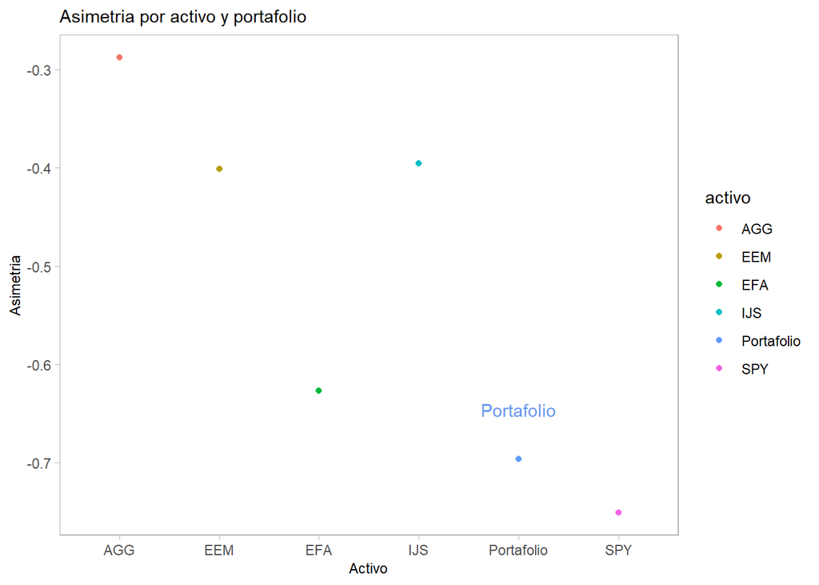

```r
retornos_semana_long %>%
  group_by(activo) %>%
  summarize(skew_accion = skewness(retorno)) %>%
  add_row(activo = "Portafolio", skew_accion = skewness(portfolio_retornos_semana)) %>%
  ggplot(aes(x = activo, y = skew_accion, colour = activo)) +
  geom_point() +
  annotate("text", x = "Portafolio", y = skewness(portfolio_retornos_semana) + 0.05,
           label = "Portafolio", color = "cornflowerblue") +
  theme_light() +
  labs(title = "Asimetria por activo y portafolio", x = "Activo", y = "Asimetria") +
  theme(plot.title = element_text(size = 11), axis.title = element_text(size = 9), panel.grid = element_blank())
```

> “¿Su portafolio mejora la asimetría de los retornos en comparación con los activos empleados en su construcción?”

**Respuesta:** no de forma clara. La asimetría del portafolio (**-0.696**) es casi tan negativa como la de SPY (-0.751) y EFA (-0.627), y bastante peor que IJS, EEM o AGG (todos entre -0.29 y -0.40). Tiene sentido: el portafolio está dominado por peso (90% en las 4 acciones), y la asimetría negativa de las caídas de mercado tiende a ocurrir de forma **correlacionada** entre activos de renta variable — diversificar reduce la dispersión (la sd), pero no elimina el sesgo compartido de “sube despacio, baja de golpe” que comparten los 4 componentes accionarios.

# 7 — Asimetría móvil (6 meses) del portafolio

```r
rolling_skew <- rollapply(data = portfolio_retornos_semana, width = ventana, FUN = skewness) %>% na.omit()

highchart(type = "stock") %>%
  hc_title(text = "Asimetria movil de 6 meses (portafolio)") %>%
  hc_add_series(rolling_skew, color = "cornflowerblue", name = "Skewness") %>%
  hc_add_theme(hc_theme_gridlight()) %>%
  hc_yAxis(title = list(text = "Skewness"), opposite = FALSE) %>%
  hc_navigator(height = 20) %>% hc_scrollbar(enabled = F) %>% hc_exporting(enabled = T)
```

[interactive chart not shown]

> “Cómo ha sido la evolución del comportamiento de la asimetría de los retornos.”

**Respuesta:** la asimetría móvil ha oscilado entre **-2.65** (ventanas dominadas por una caída fuerte, ej. 2020) y **1.07** (ventanas con una recuperación grande), con un promedio histórico de **-0.23** — mayoritariamente negativo. La ventana más reciente cierra en **0.074**, prácticamente simétrica y por encima del promedio histórico — la asimetría no es un valor fijo del portafolio, cambia bastante según qué eventos entren o salgan de la ventana de 6 meses.

# 8 — Curtosis por activo y portafolio

```r
# Este calculo de la curtosis esta centrado en 0
kurtosis(retornos_semana)
```

|  | SPY | EFA | IJS | EEM | AGG |
| --- | --- | --- | --- | --- | --- |
| Excess Kurtosis | 6.283337 | 4.720364 | 6.214768 | 1.983259 | 10.22819 |

```r
kurtosis(portfolio_retornos_semana)
```

```
## [1] 5.576707
```

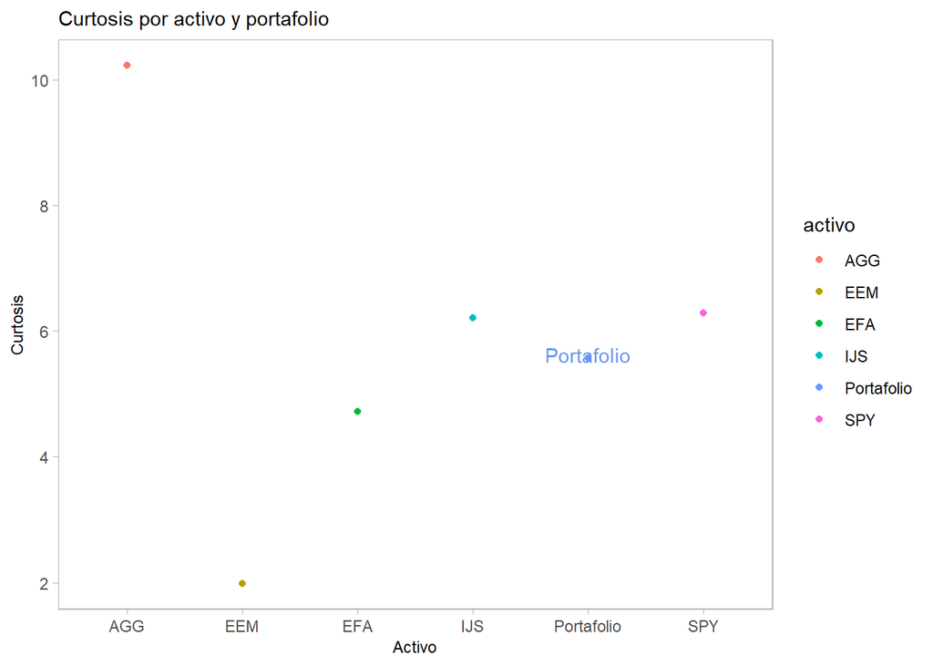

```r
retornos_semana_long %>%
  group_by(activo) %>%
  summarize(kurtosis_accion = kurtosis(retorno)) %>%
  add_row(activo = "Portafolio", kurtosis_accion = kurtosis(portfolio_retornos_semana)) %>%
  ggplot(aes(x = activo, y = kurtosis_accion, colour = activo)) +
  geom_point() +
  annotate("text", x = "Portafolio", y = kurtosis(portfolio_retornos_semana) + 0.05,
           label = "Portafolio", color = "cornflowerblue") +
  theme_light() +
  labs(title = "Curtosis por activo y portafolio", x = "Activo", y = "Curtosis") +
  theme(plot.title = element_text(size = 11), axis.title = element_text(size = 9), panel.grid = element_blank())
```

> “¿Su portafolio mejora la curtosis de los retornos en comparación con los activos empleados en su construcción?”

**Respuesta:** parcialmente. El portafolio (**5.58**) queda por debajo de SPY (6.28), IJS (6.21) y, sobre todo, de AGG (10.23, la más alta del grupo — la renta fija tiene colas mucho más gordas de lo que su baja desviación estándar sugeriría) — pero sigue por encima de EFA (4.72) y EEM (1.98, la más baja). No hay una mejora universal: diversificar sí suaviza el peor caso individual (el de AGG), pero no baja al nivel del mejor caso individual (EEM).

# 9 — Curtosis móvil (6 meses) del portafolio

```r
rolling_kurtosis <- rollapply(data = portfolio_retornos_semana, width = ventana, FUN = kurtosis) %>% na.omit()

highchart(type = "stock") %>%
  hc_title(text = "Curtosis movil de 6 meses (portafolio)") %>%
  hc_add_series(rolling_kurtosis, color = "cornflowerblue", name = "Curtosis") %>%
  hc_add_theme(hc_theme_gridlight()) %>%
  hc_yAxis(title = list(text = "Exceso de Curtosis"), opposite = FALSE) %>%
  hc_navigator(height = 20) %>% hc_scrollbar(enabled = F) %>% hc_exporting(enabled = T)
```

[interactive chart not shown]

> “Cómo ha sido la evolución del comportamiento de la curtosis de los retornos.”

**Respuesta:** la curtosis móvil oscila entre **-1.1** y **8.28** (promedio histórico 0.2) — picos altos coinciden con ventanas de 6 meses que incluyen un evento extremo aislado (un solo mes muy malo rodeado de meses tranquilos genera curtosis alta), mientras que ventanas sin sorpresas grandes quedan cerca de 0 o incluso negativas (colas más finas que una normal). La ventana más reciente cierra en **-0.78**, por debajo del promedio — el mercado reciente no ha tenido eventos extremos aislados dentro de los últimos 6 meses.

# 10 — VaR a 1 semana, 99% de confianza

```r
var_activos <- VaR(R = retornos_semana, p = alpha, invert = T)
var_activos
```

```
##             SPY         EFA        IJS         EEM         AGG
## VaR -0.08964672 -0.08724349 -0.1197135 -0.08142056 -0.03084685
```

```r
var_portafolio <- VaR(R = portfolio_retornos_semana, p = alpha, invert = T)
var_portafolio
```

```
##        retornos
## VaR -0.08173544
```

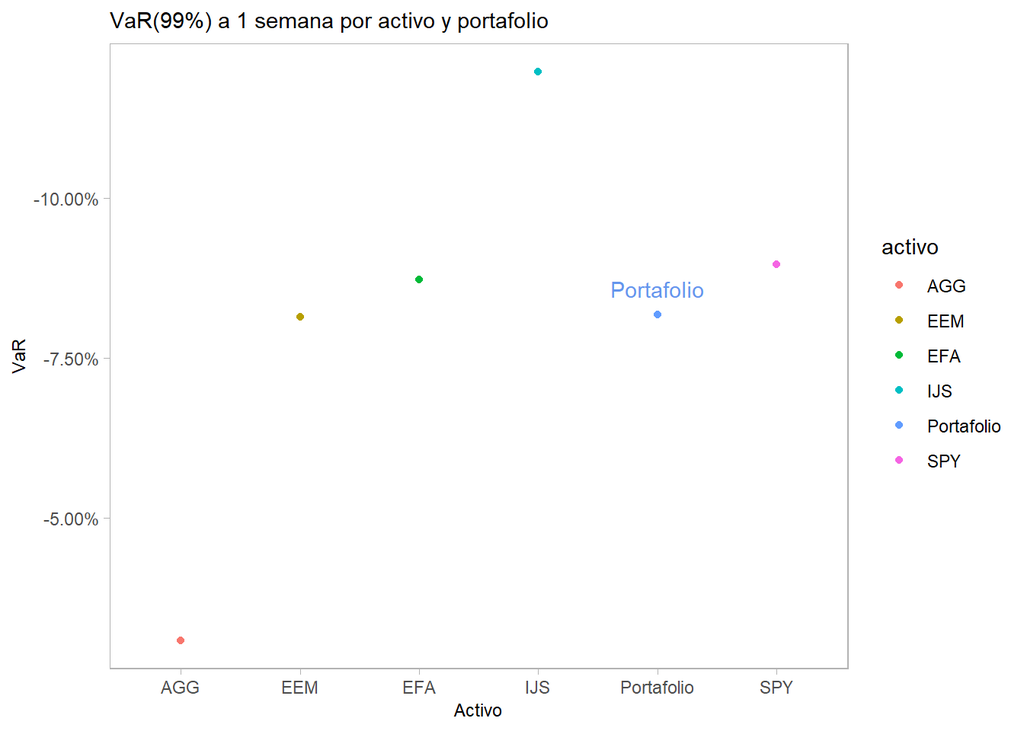

```r
retornos_semana_long %>%
  group_by(activo) %>%
  summarize(var_accion = VaR(R = retorno, invert = T, p = alpha)) %>%
  add_row(activo = "Portafolio", var_accion = VaR(R = portfolio_retornos_semana, p = alpha, invert = T)) %>%
  ggplot(aes(x = activo, y = var_accion, colour = activo)) +
  geom_point() +
  annotate("text", x = "Portafolio", y = VaR(R = portfolio_retornos_semana, p = alpha, invert = T) * 1.05,
           label = "Portafolio", color = "cornflowerblue") +
  theme_light() +
  labs(title = "VaR(99%) a 1 semana por activo y portafolio", x = "Activo", y = "VaR") +
  theme(plot.title = element_text(size = 11), axis.title = element_text(size = 9), panel.grid = element_blank()) +
  scale_y_continuous(labels = label_percent(accuracy = 0.01), transform = transform_reverse())
```

# 11 — VaR vs. retorno esperado

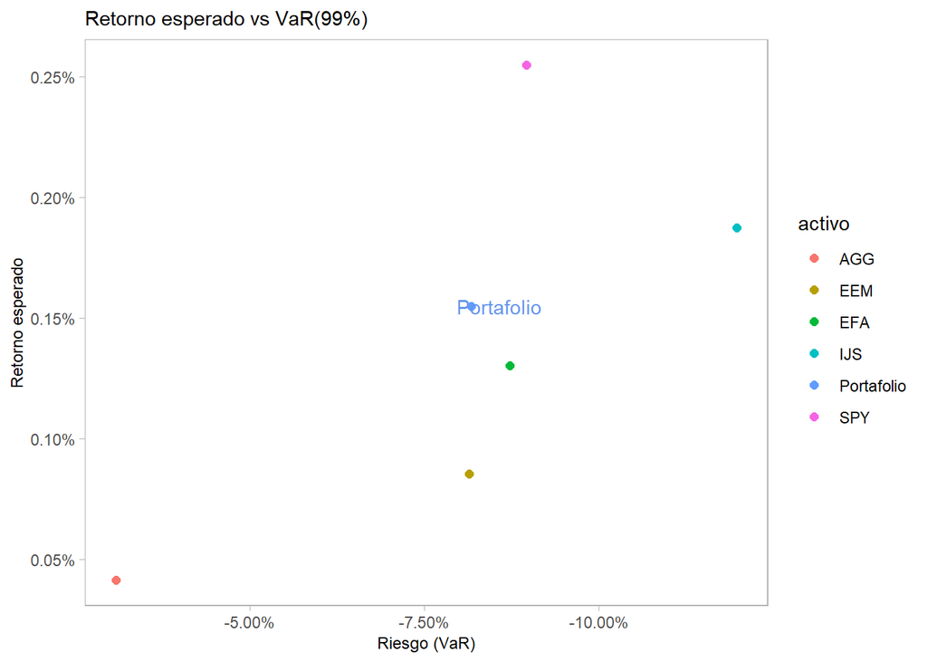

```r
retornos_semana_long %>%
  group_by(activo) %>%
  summarise(retorno_esperado = mean(retorno), var = VaR(R = retorno, p = alpha, invert = T)) %>%
  add_row(activo = "Portafolio",
          var = VaR(R = portfolio_retornos_semana, p = alpha, invert = T),
          retorno_esperado = mean(portfolio_retornos_semana)) %>%
  ggplot(aes(x = var, y = retorno_esperado, color = activo)) +
  geom_point(size = 2) +
  annotate("text", x = VaR(R = portfolio_retornos_semana, p = alpha, invert = T) * 1.05,
           y = mean(portfolio_retornos_semana), label = "Portafolio", color = "cornflowerblue") +
  theme_light() +
  labs(title = "Retorno esperado vs VaR(99%)", x = "Riesgo (VaR)", y = "Retorno esperado") +
  theme(plot.title = element_text(size = 11), axis.title = element_text(size = 9), panel.grid = element_blank()) +
  scale_y_continuous(labels = label_percent(accuracy = 0.01)) +
  scale_x_continuous(labels = label_percent(accuracy = 0.01), transform = transform_reverse())
```

# 12 — VaR móvil (6 meses) del portafolio

```r
rolling_var <- rollapply(data = portfolio_retornos_semana, width = ventana,
                          FUN = function(x) VaR(R = x, p = alpha, invert = T)) %>% na.omit()

highchart(type = "stock") %>%
  hc_title(text = "VaR(99%) movil de 6 meses (portafolio)") %>%
  hc_add_series(rolling_var*100, color = "cornflowerblue", name = "VaR") %>%
  hc_add_theme(hc_theme_gridlight()) %>%
  hc_yAxis(title = list(text = "VaR"), opposite = FALSE, reversed = TRUE, labels = list(format = "{value}%")) %>%
  hc_navigator(height = 20) %>% hc_scrollbar(enabled = F) %>% hc_exporting(enabled = T)
```

[interactive chart not shown]

> “Cómo ha sido la evolución del VaR de su portafolio.”

**Respuesta:** el VaR(99%) móvil ha llegado a **-15.96%** en su peor ventana histórica (una pérdida potencial enorme, propia de una ventana de 6 meses que incluye una crisis completa) y a **-0.93%** en la más benigna, con un promedio de **-4.56%**. La ventana más reciente cierra en **-2.95%**, mejor (menos negativa) que el promedio histórico — coherente con la volatilidad y la asimetría también más benignas de lo usual vistas en los puntos 5 y 7.

# 13 — Pérdida esperada (ES) a 1 semana, 99% de confianza

```r
es_activos <- ES(R = retornos_semana, p = alpha, invert = T)
es_activos
```

```
##            SPY         EFA        IJS         EEM         AGG
## ES -0.08964672 -0.08724349 -0.1197135 -0.09310007 -0.03084685
```

```r
es_portafolio <- ES(R = portfolio_retornos_semana, p = alpha, invert = T)
es_portafolio
```

```
##       retornos
## ES -0.08173544
```

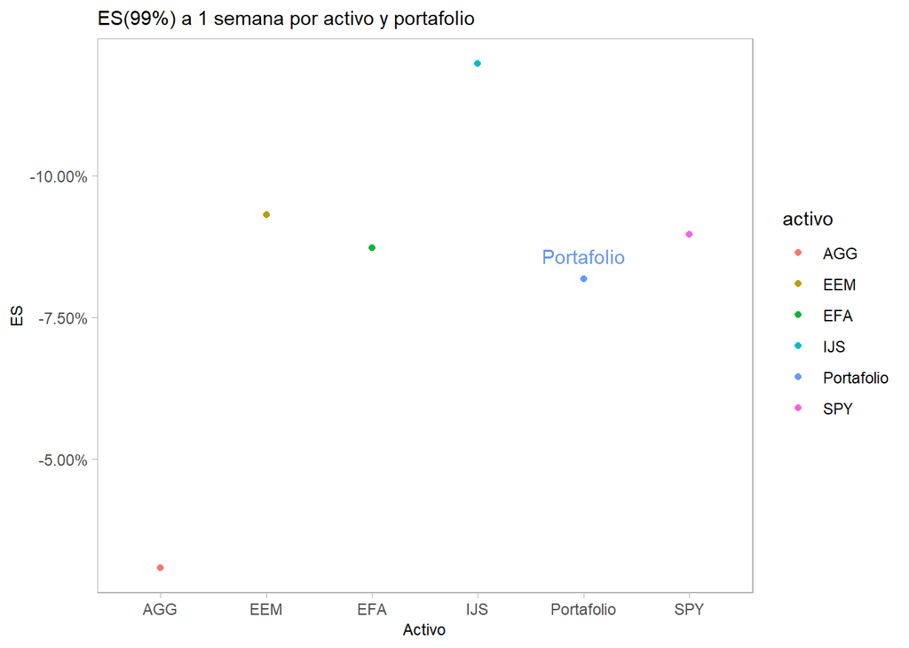

```r
retornos_semana_long %>%
  group_by(activo) %>%
  summarize(es_accion = ES(R = retorno, invert = T, p = alpha)) %>%
  add_row(activo = "Portafolio", es_accion = ES(R = portfolio_retornos_semana, p = alpha, invert = T)) %>%
  ggplot(aes(x = activo, y = es_accion, colour = activo)) +
  geom_point() +
  annotate("text", x = "Portafolio", y = ES(R = portfolio_retornos_semana, p = alpha, invert = T) * 1.05,
           label = "Portafolio", color = "cornflowerblue") +
  theme_light() +
  labs(title = "ES(99%) a 1 semana por activo y portafolio", x = "Activo", y = "ES") +
  theme(plot.title = element_text(size = 11), axis.title = element_text(size = 9), panel.grid = element_blank()) +
  scale_y_continuous(labels = label_percent(accuracy = 0.01), transform = transform_reverse())
```

> “¿El portafolio logra reducir el riesgo en comparación con los activos que lo componen?”

**Respuesta:** con ES sí es más claro que con VaR. El ES(99%) del portafolio (**-8.17%**) es mejor que las 4 acciones **sin excepción** — incluida EEM (-9.31%, cuyo VaR empataba casi con el del portafolio pero cuyo ES es notablemente peor, señal de una cola izquierda más pesada que el VaR por sí solo no alcanzaba a mostrar) — solo AGG (-3.08%) sigue siendo más seguro. Este es justo el punto a favor del ES sobre el VaR que se vio en la unidad anterior: dos activos (EEM y el portafolio) con VaR casi idéntico pueden tener un ES muy distinto si uno de los dos tiene una cola más larga.

# 14 — ES vs. retorno esperado

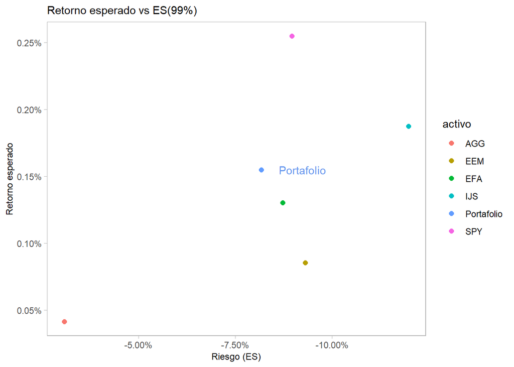

```r
retornos_semana_long %>%
  group_by(activo) %>%
  summarise(retorno_esperado = mean(retorno), ES = ES(R = retorno, p = alpha, invert = T)) %>%
  add_row(activo = "Portafolio",
          ES = ES(R = portfolio_retornos_semana, p = alpha, invert = T),
          retorno_esperado = mean(portfolio_retornos_semana)) %>%
  ggplot(aes(x = ES, y = retorno_esperado, color = activo)) +
  geom_point(size = 2) +
  annotate("text", x = ES(R = portfolio_retornos_semana, p = alpha, invert = T) * 1.13,
           y = mean(portfolio_retornos_semana), label = "Portafolio", color = "cornflowerblue") +
  theme_light() +
  labs(title = "Retorno esperado vs ES(99%)", x = "Riesgo (ES)", y = "Retorno esperado") +
  theme(plot.title = element_text(size = 11), axis.title = element_text(size = 9), panel.grid = element_blank()) +
  scale_y_continuous(labels = label_percent(accuracy = 0.01)) +
  scale_x_continuous(labels = label_percent(accuracy = 0.01), transform = transform_reverse())
```

# 15 — ES móvil (6 meses) del portafolio

```r
rolling_es <- rollapply(data = portfolio_retornos_semana, width = ventana,
                         FUN = function(x) ES(R = x, p = alpha, invert = T)) %>% na.omit()

highchart(type = "stock") %>%
  hc_title(text = "Perdida esperada (99%) movil de 6 meses (portafolio)") %>%
  hc_add_series(rolling_es*100, color = "cornflowerblue", name = "ES") %>%
  hc_add_theme(hc_theme_gridlight()) %>%
  hc_yAxis(title = list(text = "ES"), opposite = FALSE, reversed = TRUE, labels = list(format = "{value}%")) %>%
  hc_navigator(height = 20) %>% hc_scrollbar(enabled = F) %>% hc_exporting(enabled = T)
```

[interactive chart not shown]

> “Cómo ha sido la evolución de la perdida esperada de su portafolio.”

**Respuesta:** el ES(99%) móvil llega a **-47.37%** en su peor ventana histórica (una ventana de 6 meses dominada por una crisis severa, con una cola izquierda extrema) y a **-1.30%** en la más benigna, promedio **-5.89%**. La ventana más reciente cierra en **-3.88%**, mejor que el promedio histórico — el mismo patrón de calma relativa que ya se vio en volatilidad y VaR: el portafolio no está, en este momento, en una ventana de estrés según ninguna de las 5 medidas de riesgo calculadas en este taller.